# Prak02

Angga Fathan Rofiqy

2023-09-12

# I. Setting

Abaikan bagian ini. Lansung saja loncat ke `1. Tentang Data` . `Function` biar gak perlu ganti `backslash` (`\`) jadi `slash` (`/`).

```r
path <- function() gsub  ( "\\\\",  "/",  readClipboard ()  )
#Copy path, Panggil function di console
#Copy r path, paste ke var yang diinginkan
```

`Function` biar gak perlu repot buat `install("")` atau `load()` *package.*

```r
#                      -=( Install & Load Package Function )=-
install_load <- function (package1, ...)  {

   # convert arguments to vector
   packages <- c(package1, ...)

   # start loop to determine if each package is installed
   for(package in packages){

       # if package is installed locally, load
       if(package %in% rownames(installed.packages()))
          do.call('library', list(package))

       # if package is not installed locally, download, then load
       else {
          install.packages(package)
          do.call("library", list(package))
       }
   }
}
```

`Variabel` untuk warna pada `function` *box plot.*

```r
#                           -=( Default Color Palette )=-
colord <- data.frame(
  f = c('#75bfc8', 'Fill color'),       c = c('#444442', 'Stroke color'),
  oc = c('#0b5f6a', 'Outlier color'),   med = c('#c3ac8b', 'Median value color'),
  iqr = c('#c3ac8b', 'IQR3 Value'),     mean = c('#608981', 'Mean Marker'),
  v = c('#c3eca2', 'Violin'),
  stringsAsFactors = FALSE
)
```

`Variabel` untuk `ggplot` *theme.*

```r
install_load('ggplot2')
theme1 <- list(
  guides(fill="none") , #No Legends
  theme(
  text = element_text(size = 66),
  axis.title = element_text(),
  axis.text.x = element_text(hjust = 0.5, face = "bold", margin = margin(b=50)),
  plot.title = element_text(hjust = 0.5, face = "bold", margin = margin(b=50)),
  plot.subtitle = element_text(hjust = 0.5),
  panel.background = element_rect(fill = 'transparent'),
  plot.background = element_rect(fill='transparent', color=NA),
  panel.grid.major = element_line(colour = "grey50"),
  axis.line = element_line(linewidth = 5, colour = "grey80"))
)
```

*Box Plot* `Function`.

```r
#                           -=( Box Plot Function )=-
boxp <- function(dt, cp=colord, labs=lab1){ #data, color palette, label
  install_load('ggplot2')
  b <- ggplot(data=dt, aes(y="", x=y)) +
        #Violin Plot
        geom_violin(scale="count", fill=cp$v[1], color=NA, alpha=0.5,
                    trim = FALSE) +
        #Box Plot
        geom_boxplot(fill=cp$f[1], color=cp$c[1],
                     outlier.size=15, outlier.color=cp$oc[1],
                     alpha=0.7,notch=T, width = 0.25) +
        #Median Value
        stat_summary(geom="text", fun=median,
                     aes(label=sprintf("%1.1f", after_stat(x))),
                     position=position_nudge(y=0.425), size=16, color=cp$med[1]) +
        #IQR1 Value
        stat_summary(geom="text", fun="quantile", fun.args=list(probs=0.25),
                     aes(label=sprintf("%1.1f", after_stat(x))),
                     position=position_nudge(y=-0.425), size=16, color=cp$iqr[1]) +
        #IQR3 Value
        stat_summary(geom="text", fun="quantile", fun.args=list(probs=0.75),
                     aes(label=sprintf("%1.1f", after_stat(x))),
                     position=position_nudge(y=-0.425), size=16, color=cp$iqr[1]) +
        #Mean Marker
        stat_summary(fun='mean', geom="point",colour=cp$mean[1],
                     shape=18, size=16, alpha=0.75) +
        #Title
        ggtitle(labs$title) +
        theme(plot.title = element_text(hjust = 0.5)) + #Title Position
        #Labels
        ylab(labs$ylab) + xlab(labs$xlab) +
        #Mean Value
        geom_text(data = data.frame(mean = round(mean(dt$y), 2))
                    , aes(label = paste0("Mean : ",mean), x = mean),
                  angle=45, size=16, vjust=-0.5, hjust=0.5, color=cp$mean[1]) +
        #Theme
        theme1
return(b)
}
```

*Default* *label* untuk `function` *box plot.*

```r
#                            -=( Default Label/Title )=-
lab1 <- data.frame(title='Distribution of Data X', ylab='', xlab='Data X')
```

# A. Tentang Data

Dataset ini dibangun dari dataset awal yang terdiri dari $600.000$ data transaksi yang dikumpulkan dalam waktu 6 tahun (periode 2014-2019), yang mencatat tanggal dan waktu penjualan, nama merek obat farmasi, dan jumlah yang terjual. Data ini diekspor dari sistem *Point-of-Sale* di apotek individu. Kelompok obat yang dipilih dari dataset (57 obat) diklasifikasikan ke dalam kategori berikut dalam Sistem Klasifikasi Anatomi Terapeutik Kimia (ATC):

1. M01AB - Produk antiinflamasi dan antirheumatik, non-steroid, Turunan asam asetat dan substansi terkait
2. M01AE - Produk antiinflamasi dan antirheumatik, non-steroid, Turunan asam propionat
3. N02BA - Analgesik dan antipiretik lainnya, Asam salisilat dan turunannya N02BE/B -
4. Analgesik dan antipiretik lainnya, Pirazolona dan Anilida
5. N05B - Obat psikoleptik, Obat ansiolitik
6. N05C - Obat psikoleptik, Obat hipnotik dan sedatif
7. R03 - Obat untuk penyakit saluran napas obstruktif
8. R06 - Antihistamin untuk penggunaan sistemik

Data penjualan diambil ulang dalam periode per jam, per hari, per minggu, dan per bulan. Data sudah diproses sebelumnya, termasuk deteksi dan penanganan outlier serta pengisian data yang hilang.

Data yang akan saya gunakan adalah data dalam periode per bulan. Obat `M01AB` dan `M01AE` merupakan obat yang sama, namun dengan bahan dasar yang berbeda. Saya penasaran “*Apakah penjualan obat `M01AB` dipengaruhi oleh penjualan obat `M01AB` dan obat-obat lainnya?“* Sehingga saya memilih Peubah `M01AB` sebagai peubah respon `Y`. Dan peubah lainnya sebagai peubah penjelas `X`.

### Import Data

```r
install_load('rio')
raw.data <- import("https://raw.githubusercontent.com/Zen-Rofiqy/STA1341-MPDW/main/Pertemuan%202/salesmonthly.csv")
```

### Assign Variable

```r
install_load('dplyr')
data <- raw.data[,2:9] %>%
  rename_all(~ c('y', 'x1', 'x2', 'x3', 'x4', 'x5', 'x6', 'x7'))
```

# B. Explorasi

### Sebaran Peubah Respon

```r
boxp( dt = data,
  labs = data.frame(title='Sebaran Peubah y', ylab='', xlab='Obat M01AB')
  )
```

[figure not shown]

### Matriks Korelasi

```r
install_load('psych')
```

```r
pairs.panels(data,
             method = "pearson", # correlation method
             hist.col = "#00AFBB", #Coloring histogram
             density = TRUE,  # show density plots
             ellipses = TRUE, # show correlation ellipses
             smooth = TRUE, #show loess smooths
             pch = 20, #Scatter = cirlce / dot
             rug = TRUE, #Rug under histogram
             stars = TRUE #Significance of corr
             )
```

[figure not shown]

# C. Regresi

### Model Regresi

```r
model <- lm(y ~ x1 + x2 + x3 + x4 + x5 + x6 + x7, data)
summary(model)
```

```
##
## Call:
## lm(formula = y ~ x1 + x2 + x3 + x4 + x5 + x6 + x7, data = data)
##
## Residuals:
##     Min      1Q  Median      3Q     Max
## -55.649 -11.046   0.109  13.309  62.473
##
## Coefficients:
##             Estimate Std. Error t value Pr(>|t|)
## (Intercept) 51.26828   15.04508   3.408  0.00116 **
## x1           0.45722    0.16379   2.792  0.00696 **
## x2           0.16184    0.14071   1.150  0.25451
## x3           0.01414    0.01764   0.802  0.42574
## x4          -0.02988    0.04765  -0.627  0.53296
## x5          -0.07883    0.43916  -0.179  0.85813
## x6           0.01912    0.05446   0.351  0.72666
## x7           0.23362    0.07338   3.184  0.00228 **
## ---
## Signif. codes:  0 '***' 0.001 '**' 0.01 '*' 0.05 '.' 0.1 ' ' 1
##
## Residual standard error: 24.05 on 62 degrees of freedom
## Multiple R-squared:  0.4758, Adjusted R-squared:  0.4166
## F-statistic:  8.04 on 7 and 62 DF,  p-value: 6.328e-07
```

### Plot Sisaan & Q-Q Plot

```r
sisaan<- residuals(model)
fitValue<- predict(model)

#Diagnostik dengan eksploratif
par(mfrow = c(2,2)) #Buat 4 plot

#Q-Q Plot
qqnorm(sisaan)
qqline(sisaan, col = "steelblue", lwd = 2)

#Sisaan vs Fitted Values
plot(fitValue, sisaan, col = "steelblue", pch = 20,
     xlab = "Sisaan", ylab = "Fitted Values", main = "Sisaan vs Fitted Values")
abline(a = 0, b = 0, lwd = 2)

#Histogram
hist(sisaan, col = "steelblue")

#Sisaan vs Order
plot(1:length(sisaan), sisaan, col = "steelblue", pch = 20,
     xlab = "Sisaan",
     ylab = "Order", main = "Sisaan vs Order")
lines(1:length(sisaan), sisaan, col = "red")
abline(a = 0, b = 0, lwd = 2)
```

[figure not shown]

Dua plot di samping kiri digunakan untuk melihat apakah sisaan menyebar normal. Normal Q-Q Plot di atas menunjukkan bahwa sisaan cenderung menyebar normal dan histogram dari sisaan menunjukkan hal yang serupa. Selanjutnya, dua plot di samping kanan digunakan untuk melihat autokorelasi. Terlihat ada pola pada sisaan yang ditunjukkan oleh Plot Sisaan vs *Fitted Value* dan terutama pada Plot Sisaan vs *Order* yang terlihat dengan garis warna merahnya yang membentuk pola. Ini merupakan tanda adanya autokorelasi.

### Dengan ggplot2

```r
install_load('ggplot2','cowplot')
# Membuat QQ Plot
qq_plot <- ggplot(data, aes(sample = y)) +
  geom_qq(fill=NA, alpha=0.5) +
  geom_qq_line(color = "steelblue") +
  labs(x = "Theoretical Quantiles", y = "Sample Quantiles") +
  ggtitle("QQ Plot") + theme_minimal()

# Membuat plot sisaan vs Fitted Values dengan ggplot2
plot1 <- ggplot(data, aes(x = fitted(model), y = residuals(model))) +
  geom_point(col = "steelblue", pch = 20) +
  geom_abline(intercept = 0, slope = 0, color = "black",
              size = 0.75, alpha=0.5) +
  labs(x = "Fitted Values", y = "Residuals") +
  ggtitle("Residuals vs Fitted Values") + theme_minimal()
# Membuat histogram sisaan dengan ggplot2
plot2 <- ggplot(data, aes(x = residuals(model))) +
  geom_histogram(binwidth = 10, fill = "steelblue", color = "black") +
  labs(x = "Residuals", y = "Frequency") +
  ggtitle("Histogram of Residuals") + theme_minimal()

# Membuat plot sisaan vs Order dengan ggplot2
plot3 <- ggplot(data, aes(x = 1:length(residuals(model)), y = residuals(model))) +
  geom_point(col = "steelblue", pch = 20) +
  geom_abline(intercept = 0, slope = 0, color = "black",
              size = 1, alpha=0.5) +
  geom_line(aes(x = 1:length(residuals(model)),
                y = residuals(model)), color = "red", alpha=0.5) +
  labs(x = "Order", y = "Residuals") +
  ggtitle("Residuals vs Order") + theme_minimal()

# Menggabungkan semua plot dengan cowplot
plot_grid(qq_plot, plot1, plot2, plot3, nrow = 2, ncol = 2)
```

[figure not shown]

Untuk lebih lanjut akan digunakan uji formal melihat normalitas sisaan dan plot ACF dan PACF untuk melihat apakah ada autokorelasi atau tidak.

### Melihat Sisaan Menyebar Normal/Tidak

$H_0$ : Sisaan mengikuti sebaran normal

$H_1$ : Sisaan **tidak** mengikuti sebaran normal

```r
shapiro.test(sisaan)
```

```
##
##  Shapiro-Wilk normality test
##
## data:  sisaan
## W = 0.99006, p-value = 0.8574
```

```r
ks.test(sisaan, "pnorm", mean=mean(sisaan), sd=sd(sisaan))
```

```
##
##  Exact one-sample Kolmogorov-Smirnov test
##
## data:  sisaan
## D = 0.083832, p-value = 0.6774
## alternative hypothesis: two-sided
```

### ACF dan PACF identifikasi autokorelasi

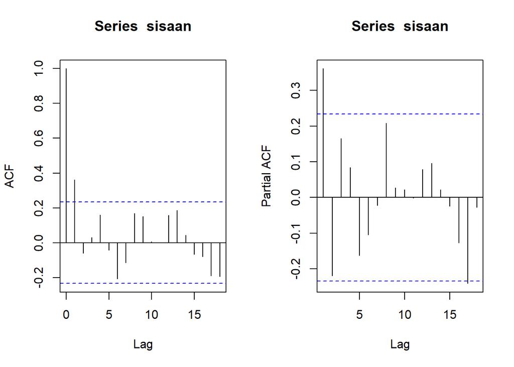

```r
par(mfrow = c(1,2))
acf(sisaan)
pacf(sisaan)
```

Berdasarkan plot ACF dan PACF, terlihat semua dalam rentang batas dan hanya ada satu yang signifikan (terindikasi adanya autokorelasi) pada plot ACF dan ada satu pada Plot PACF Namun, untuk lebih memastikan akan dilakukan uji formal dengan uji Durbin Watson.

### Deteksi autokorelasi dengan uji-Durbin Watson

$H_0$ : Tidak ada autokorelasi

$H_1$ : Ada autokorelasi

```r
install_load('randtests')
runs.test(model$residuals)
```

```
##
##  Runs Test
##
## data:  model$residuals
## statistic = -1.6856, runs = 29, n1 = 35, n2 = 35, n = 70, p-value =
## 0.09188
## alternative hypothesis: nonrandomness
```

```r
install_load('lmtest')
dwtest(model)
```

```
##
##  Durbin-Watson test
##
## data:  model
## DW = 1.2495, p-value = 0.0001048
## alternative hypothesis: true autocorrelation is greater than 0
```

Berdasarkan hasil DW Test, didapatkan nilai $DW = 1.2495$ dan $p.value = 0.0001048$. Dengan nilai $p.value < 0.05$ dapat disimpulkan bahwa **tolak** $H_0$, cukup bukti mengatakan adanya autokorelasi. Oleh karena itu, diperlukan penanganan autokorelasi. Penanganan yang akan digunakan menggunakan dua metode, yaitu Cochrane-Orcutt dan Hildret-Lu.

# D. Penanganan Autokorelasi

### Metode Cochrane-Orcutt

Penanganan metode Cochrane-Orcutt dapat dilakukan dengan bantuan packages Orcutt pada aplikasi `R` maupun secara manual. Berikut ini ditampilkan cara menggunakan bantuan `library` *packages* `Orcutt`.

```r
install_load('orcutt')
modelCO <- cochrane.orcutt(model)
modelCO
```

```
## Cochrane-orcutt estimation for first order autocorrelation
##
## Call:
## lm(formula = y ~ x1 + x2 + x3 + x4 + x5 + x6 + x7, data = data)
##
##  number of interaction: 28
##  rho 0.623643
##
## Durbin-Watson statistic
## (original):    1.24950 , p-value: 1.048e-04
## (transformed): 1.91190 , p-value: 3.785e-01
##
##  coefficients:
## (Intercept)          x1          x2          x3          x4          x5
##   26.693862    0.318248    0.378026   -0.000166    0.097630   -0.029786
##          x6          x7
##    0.020880    0.175696
```

Hasil keluaran model setelah dilakukan penanganan adalah sebagai berikut. $y_i= 26.693862 + 0.318248x_1 + 0.378026 - 0.000166x_3 + 0.097630x_4 - 0.029786x_5 + 0.020880x_6 + 0.175696x_7$ Hasil juga menunjukkan bahwa nilai DW dan p-value meningkat dari $1.048 \times 10^{-4}$ menjadi $0.3785$, dengan nilai $p.value > 0.05$, artinya belum cukup bukti menyatakan bahwa sisaan terdapat autokorelasi pada taraf nyata $5\%$.

### Rho optimum

```r
rho <- modelCO$rho
rho
```

```
## [1] 0.6236433
```

Untuk nilai $\hat{\rho}$ optimum yang digunakan adalah $0.6236433$.

### Transformasi Manual

Selanjutnya akan dilakukan transformasi secara manual dengan : `data tanpa amatan pertama` - `data tanpa amatan terakhir` $\times$ `rho`

```r
trans <- data[-1,] - data[-nrow(data),] * rho
modelCOmanual <- lm(y ~ x1 + x2 + x3 + x4 + x5 + x6 + x7, trans)
summary(modelCOmanual)
```

```
##
## Call:
## lm(formula = y ~ x1 + x2 + x3 + x4 + x5 + x6 + x7, data = trans)
##
## Residuals:
##     Min      1Q  Median      3Q     Max
## -46.159 -13.079  -1.617  12.868  47.550
##
## Coefficients:
##               Estimate Std. Error t value Pr(>|t|)
## (Intercept) 10.0464144  5.8607533   1.714   0.0916 .
## x1           0.3182475  0.1376392   2.312   0.0242 *
## x2           0.3780261  0.1476258   2.561   0.0129 *
## x3          -0.0001661  0.0148848  -0.011   0.9911
## x4           0.0976296  0.0611365   1.597   0.1155
## x5          -0.0297857  0.4130362  -0.072   0.9427
## x6           0.0208799  0.0531617   0.393   0.6959
## x7           0.1756964  0.0785588   2.236   0.0290 *
## ---
## Signif. codes:  0 '***' 0.001 '**' 0.01 '*' 0.05 '.' 0.1 ' ' 1
##
## Residual standard error: 21.52 on 61 degrees of freedom
## Multiple R-squared:  0.5823, Adjusted R-squared:  0.5344
## F-statistic: 12.15 on 7 and 61 DF,  p-value: 1.33e-09
```

### Mencari Penduga Koefisien Regresi setelah Transformasi ke Persamaan Awal

```r
#Mencari Penduga Koefisien Regresi setelah Transformasi ke Persamaan Awal
b0bintang <- coef(modelCOmanual) %>%
  as.data.frame() %>%
  t() %>%
  as_tibble() %>%
  setNames(c("b0", "b1", "b2", "b3", "b4", "b5", "b6", "b7"))
b0bintang$b0 <- b0bintang$b0/(1 - rho)
install_load('knitr','kableExtra')
kable(b0bintang) %>% kable_styling()
```

| b0 | b1 | b2 | b3 | b4 | b5 | b6 | b7 |
| --- | --- | --- | --- | --- | --- | --- | --- |
| 26.69386 | 0.3182475 | 0.3780261 | -0.0001661 | 0.0976296 | -0.0297857 | 0.0208799 | 0.1756964 |

Hasil perhitungan koefisien regresi tersebut akan menghasilkan hasil yang sama dengan model yang dihasilkan menggunakan *packages*.

# E. Metode Hildreth-Lu

Penanganan kedua adalah menggunakan metode Hildreth-Lu. Metode ini akan mencari nilai SSE terkecil dan dapat dicari secara manual maupun menggunakan packages. Jika menggunakan packages, gunakan `library` *packages* `HORM`.

### Penanganan Autokorelasi Hildreth lu

```r
hildreth.lu.func<- function(r, model){
  x1 <- model.matrix(model)[,2]
  x2 <- model.matrix(model)[,3]
  x3 <- model.matrix(model)[,4]
  x4 <- model.matrix(model)[,5]
  x5 <- model.matrix(model)[,6]
  x6 <- model.matrix(model)[,7]
  x7 <- model.matrix(model)[,8]

  y <- model.response(model.frame(model))

  n <- length(y)
  t <- 2:n

  y <- y[t]-r*y[t-1]

  x1 <- x1[t]-r*x1[t-1]
  x2 <- x2[t]-r*x2[t-1]
  x3 <- x3[t]-r*x3[t-1]
  x4 <- x4[t]-r*x4[t-1]
  x5 <- x5[t]-r*x5[t-1]
  x6 <- x6[t]-r*x6[t-1]
  x7 <- x7[t]-r*x7[t-1]

  return(lm(y~x1+x2+x3+x4+x5+x6+x7))
}
```

### Pencarin rho yang meminimumkan SSE

```r
r <- c(seq(0.1,0.9, by= 0.1))
tab <- data.frame("rho" = r, "SSE" = sapply(r,
                    function(i)deviance(hildreth.lu.func(i, model)) ) )

kable(round(tab, 4)) %>% kable_styling()
```

| rho | SSE |
| --- | --- |
| 0.1 | 33474.50 |
| 0.2 | 31622.80 |
| 0.3 | 30219.01 |
| 0.4 | 29213.27 |
| 0.5 | 28563.52 |
| 0.6 | 28265.17 |
| 0.7 | 28402.90 |
| 0.8 | 29189.53 |
| 0.9 | 30918.32 |

```r
min(tab$SSE)
```

```
## [1] 28265.17
```

```r
rOpt <- seq(0.4,0.5, by= 0.001)
tabOpt <- data.frame("rho" = rOpt, "SSE" = sapply(rOpt, function(i){deviance(hildreth.lu.func(i, model))}))
kable(head(tabOpt[order(tabOpt$SSE),])) %>% kable_styling()
```

|  | rho | SSE |
| --- | --- | --- |
| 101 | 0.500 | 28563.52 |
| 100 | 0.499 | 28568.33 |
| 99 | 0.498 | 28573.17 |
| 98 | 0.497 | 28578.04 |
| 97 | 0.496 | 28582.95 |
| 96 | 0.495 | 28587.89 |

```r
min(tabOpt$SSE)
```

```
## [1] 28563.52
```

### Grafik SSE optimum

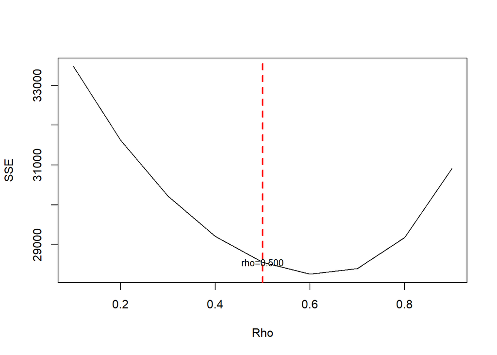

```r
par(mfrow = c(1,1))
plot(tab$SSE ~ tab$rho , type = "l", xlab = "Rho", ylab = "SSE")
abline(v = tabOpt[tabOpt$SSE==min(tabOpt$SSE),"rho"], lty = 2, col="red",lwd=2)
text(x=0.500, y=28563.52, labels = "rho=0.500", cex = 0.8)
```

### Model terbaik

```r
modelHL <- hildreth.lu.func(0.500, model)
summary(modelHL)
```

```
##
## Call:
## lm(formula = y ~ x1 + x2 + x3 + x4 + x5 + x6 + x7)
##
## Residuals:
##     Min      1Q  Median      3Q     Max
## -48.322 -11.988  -0.674  11.744  43.963
##
## Coefficients:
##              Estimate Std. Error t value Pr(>|t|)
## (Intercept) 16.276334   7.546434   2.157   0.0350 *
## x1           0.351409   0.143260   2.453   0.0170 *
## x2           0.337828   0.147281   2.294   0.0253 *
## x3           0.001195   0.015469   0.077   0.9387
## x4           0.057134   0.058611   0.975   0.3335
## x5           0.012208   0.435671   0.028   0.9777
## x6           0.032262   0.053251   0.606   0.5469
## x7           0.189946   0.077786   2.442   0.0175 *
## ---
## Signif. codes:  0 '***' 0.001 '**' 0.01 '*' 0.05 '.' 0.1 ' ' 1
##
## Residual standard error: 21.64 on 61 degrees of freedom
## Multiple R-squared:  0.5548, Adjusted R-squared:  0.5037
## F-statistic: 10.86 on 7 and 61 DF,  p-value: 8.287e-09
```

### Transformasi Balik

```r
cat("y = ", coef(modelHL)[1]/(1-0.500), "+", coef(modelHL)[2],"x", sep = "")
```

```
## y = 32.55267+0.351409x
```

### Deteksi autokorelasi

```r
dwtest(modelHL)
```

```
##
##  Durbin-Watson test
##
## data:  modelHL
## DW = 1.7683, p-value = 0.1576
## alternative hypothesis: true autocorrelation is greater than 0
```

Hasil uji Durbin-Watson juga menunjukkan bawah nilai DW sebesar $1.7683$ berada pada selang daerah tidak ada autokorelasi. Hal tersebut juga didukung oleh *p-value* sebesar $0.1576$ , di mana $p.value > \alpha (5\%).$ Artinya tak tolak $H_0$ atau belum cukup bukti menyatakan bahwa ada autokorelasi dalam data nilai penjualan obat dengan metode Hildreth-Lu pada taraf nyata 5%.

Terakhir, akan dibandingkan nilai SSE dari ketiga metode (metode awal, metode Cochrane-Orcutt, dan Hildreth-Lu).

### Perbandingan

```r
sseModelawal <- anova(model)$`Sum Sq`[-c(1:7)]
sseModelCO <- anova(modelCOmanual)$`Sum Sq`[-c(1:7)]
sseModelHL <- anova(modelHL)$`Sum Sq`[-c(1:7)]
mseModelawal <- sseModelawal/nrow(data)
mseModelCO <- sseModelCO/nrow(data)
mseModelHL <- sseModelHL/nrow(data)
akurasi <- matrix(c(sseModelawal,sseModelCO,sseModelHL,
                    mseModelawal,mseModelCO,mseModelHL),nrow=2,ncol=3,byrow = T)
colnames(akurasi) <- c("Model Awal", "Model Cochrane-Orcutt", "Model Hildreth-Lu")
row.names(akurasi) <- c("SSE","MSE")
akurasi
```

```
##     Model Awal Model Cochrane-Orcutt Model Hildreth-Lu
## SSE 35854.4575            28252.6084        28563.5224
## MSE   512.2065              403.6087          408.0503
```

# II. Kesimpulan